# Data Visualization with `ggplot2`

`grid.arrange()` command from `gridExtra` package combines your `ggplot2` objects into a single window. To this end, you have to assign an object name to each plot.

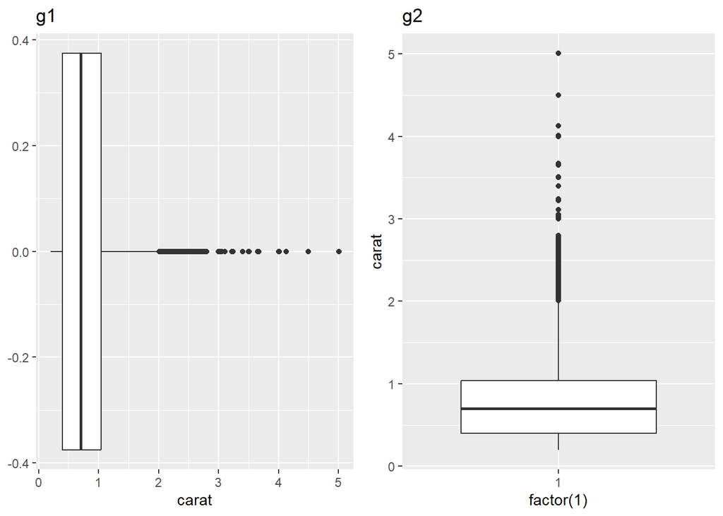

```r
g1<-ggplot(diamonds,aes(x=carat))+geom_boxplot()+labs(title="g1")
g2<-ggplot(diamonds,aes(x=factor(1),y=carat))+geom_boxplot()+labs(title="g2") #factor(1) a must
library(gridExtra)
grid.arrange(g1,g2,ncol=2)
```

**A box plot** can be used to observe the distribution of a continuous variable, but it is not particularly successful in identifying multimodal distributions. However, it is effective in detecting extreme outliers. In fact, to create a box plot in ggplot2, you typically need two variables. However, if you want to create a box plot for a single variable, you can assign a factor object to the x-axis.

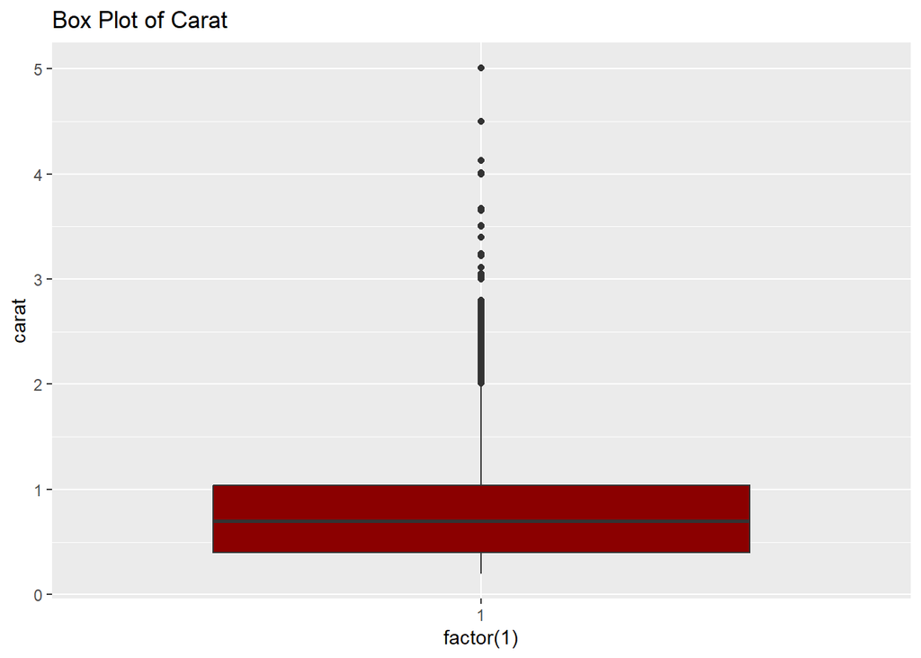

```r
ggplot(diamonds,aes(x=factor(1),y=carat))+geom_boxplot(fill="darkred")+labs(title="Box Plot of Carat")
```

**Question: What is the association between carat and price?**

**Scatter Plot**

When you are interested in the association between two continuous variables, **scatter plot** is useful. `geom_point()` is the geometric function.

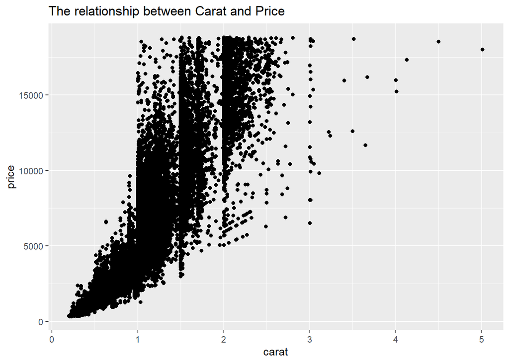

```r
ggplot(diamonds,aes(x=carat,y=price))+geom_point()+labs(title = "The relationship between Carat and Price")
```

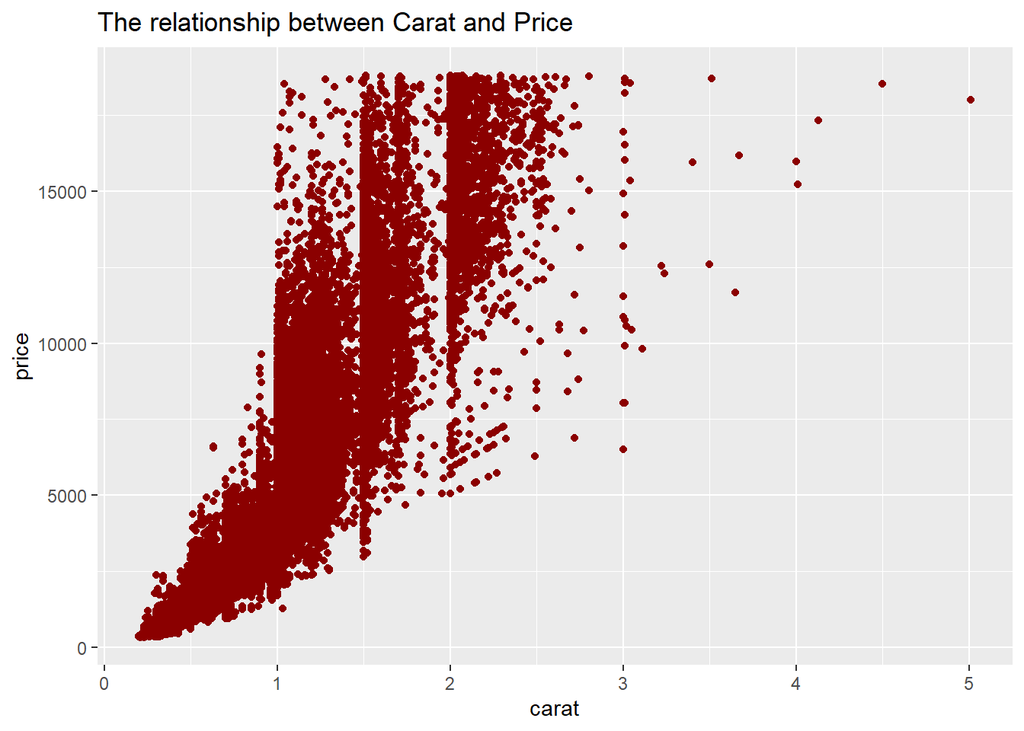

```r
ggplot(diamonds,aes(x=carat,y=price))+geom_point(col="darkred")+labs(title = "The relationship between Carat and Price")
```

**Adding trend line**

For example, to add a trend line using a different modeling technique such as loess (local regression), you can specify method = “loess” within the geom_smooth function. This will fit a smooth curve to the data instead of a straight line. Similarly, you can explore other available methods, such as generalized additive models (GAMs) or polynomial regression, depending on the nature of your data and the relationship you want to capture.

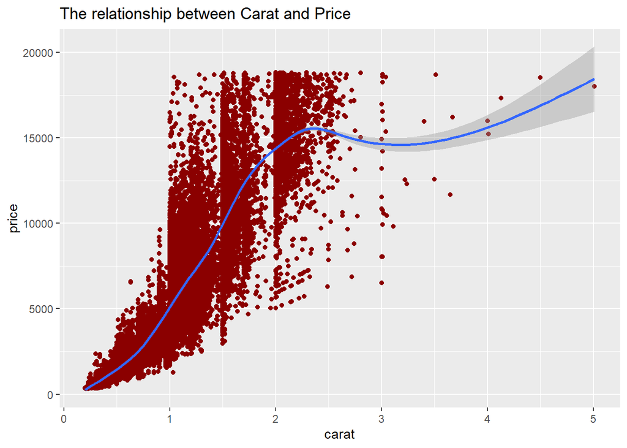

```r
ggplot(diamonds,aes(x=carat,y=price))+geom_point(col="darkred")+labs(title = "The relationship between Carat and Price")+geom_smooth()
```

Price and carat have strong positive relationship but some outliers exist that violates the relationship.

**More and More**

**Question: What is the association between carat and price by cut type?**

Facet in ggplot

Faceting is a technique that divides the chart window into multiple smaller sections, forming a grid-like layout where each section displays a similar chart. Typically, each section represents a specific group or subset of the dataset, showcasing the same type of graph. This approach, often referred to as small multiples, provides a way to compare and analyze different segments of the data in a concise and structured manner.

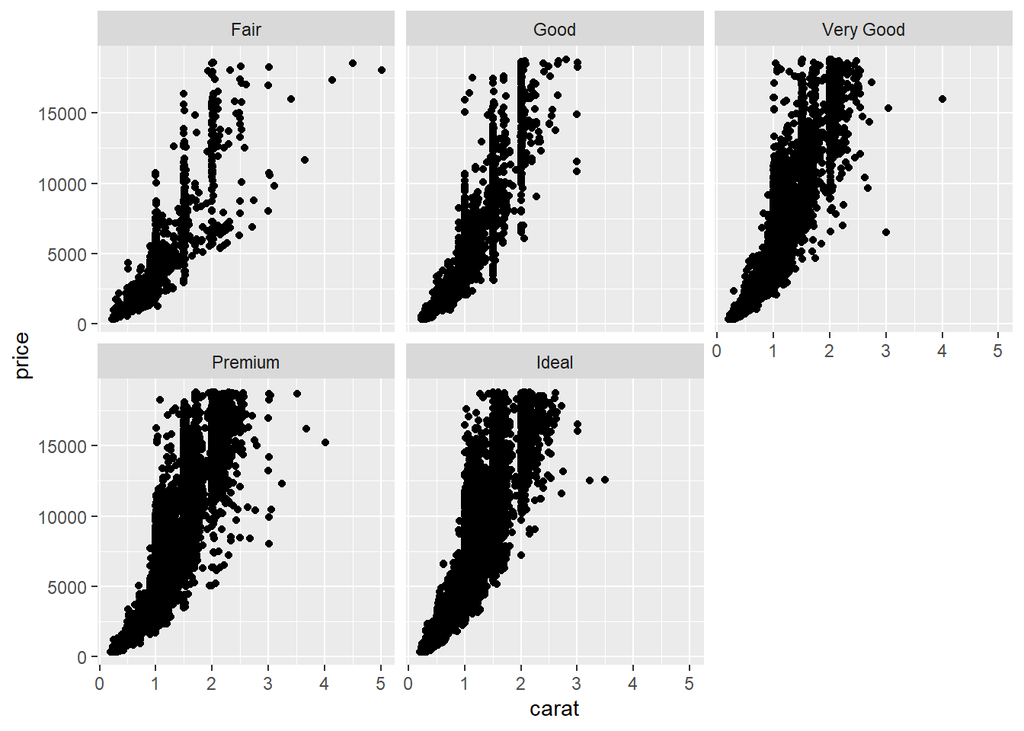

```r
ggplot(diamonds,aes(x=carat,y=price))+geom_point()+facet_wrap(.~cut)
```

```r
# .~ is must
```

**Question: What is the association between carat and price by depth and cut?**

Here, we would like to represent three numerical variables and one categorical variable visually at the same time.

*Bubble Plot* : A bubble plot is a scatter plot with a third numeric variable mapped to circle size. It also enable us to include one categorical variable as a fourth one.

In order to explain the concept, I would like to use a sample of data. (Prevent the visual overplotting.)

```r
set.seed(123)
s = diamonds[sample(1:53940,50),]
```

You can add your third variable, which is the numerical one, via `size` argument, and add your fourth variable, which is the categorical one, via `col` argument.

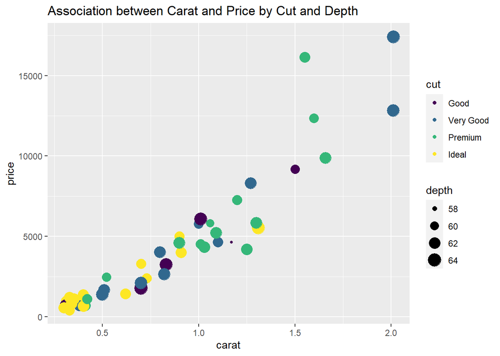

```r
ggplot(s,aes(x=carat,y=price,size=depth,col=cut))+geom_point()+labs(title="Association between Carat and Price by Cut and Depth")
```

**Question: How does depth distribute by clarity?**

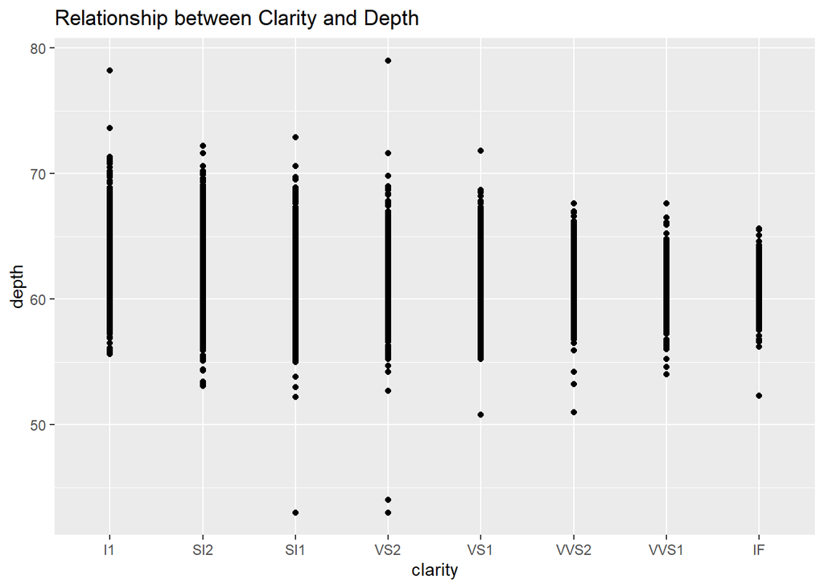

```r
ggplot(diamonds,aes(x=clarity,y=depth))+geom_point()+labs(title="Relationship between Clarity and Depth")
```

Such plot suffers from overplotting which makes interpretation harder. It is a common problem seen in data set having large number of observations (for this data we have 53940 observations.)

There are some suggested solutions for this problem. To see the list click [here](https://www.data-to-viz.com/caveat/overplotting.html), and one of them is jittering.

*Jitter Plot:* Random noise are added to the location of each point to remove overplotting.

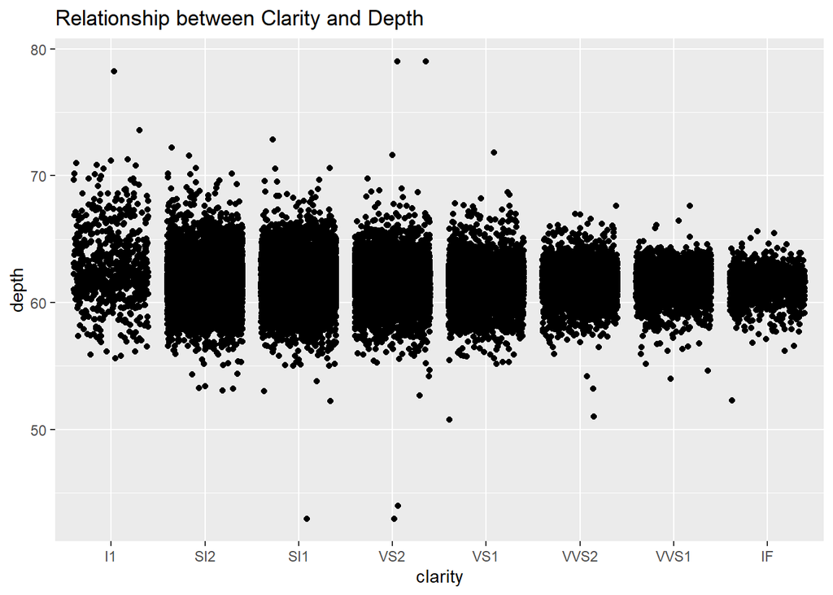

```r
ggplot(diamonds,aes(x=clarity,y=depth))+geom_point(position="jitter")+labs(title="Relationship between Clarity and Depth")
```

```r
#position="jitter" is must
```

To see the effect of jittering, let us use the sample data set, using sample of data is one of the solution of overplotting.

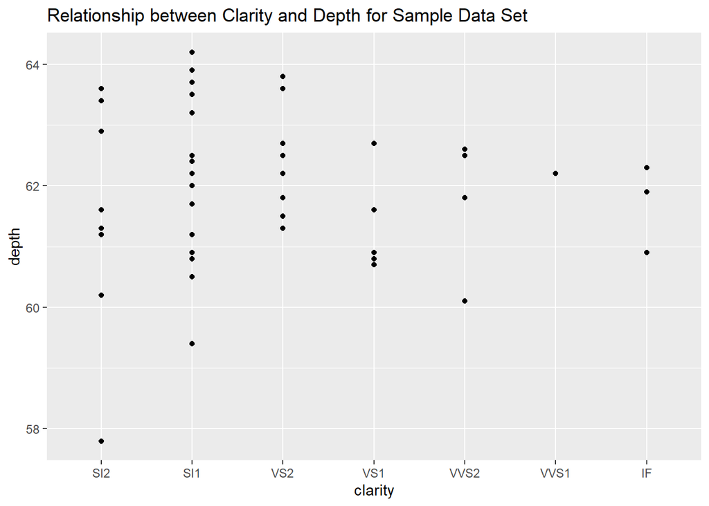

```r
ggplot(s,aes(x=clarity,y=depth))+geom_point()+labs(title="Relationship between Clarity and Depth for Sample Data Set")
```

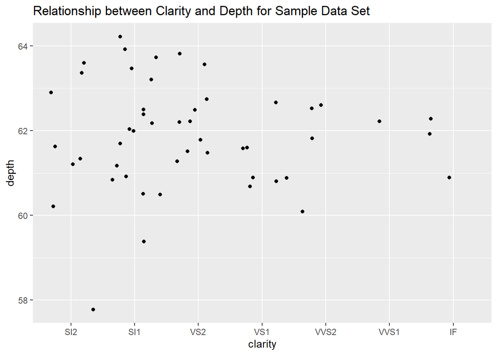

```r
ggplot(s,aes(x=clarity,y=depth))+geom_point(position="jitter")+labs(title="Relationship between Clarity and Depth for Sample Data Set")
```

### **More and More**

**Question: How diamonds prices distribute over cut type?**

**Box Plot**

In addition to showcasing a single variable, box plots are also useful for observing the variation of a continuous variable across different levels of a categorical variable. By creating box plots for each level of the categorical variable, we can visually compare the distributions, central tendencies, and spreads of the continuous variable within each category. This allows us to identify potential differences, outliers, and trends across the categories, providing valuable insights into the relationship between the continuous and categorical variables.

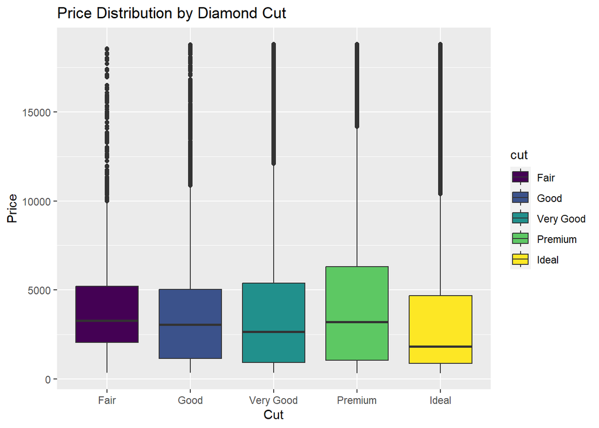

```r
ggplot(diamonds, aes(x = cut, y = price, fill = cut)) +
  geom_boxplot() +
  labs(x = "Cut", y = "Price", title = "Price Distribution by Diamond Cut")
```

*Violin Plot:* Violin plots are similar to box plots, except that they also show the kernel probability density of the data at different values. `geom_violin()` is the geometric function for the violin plot.

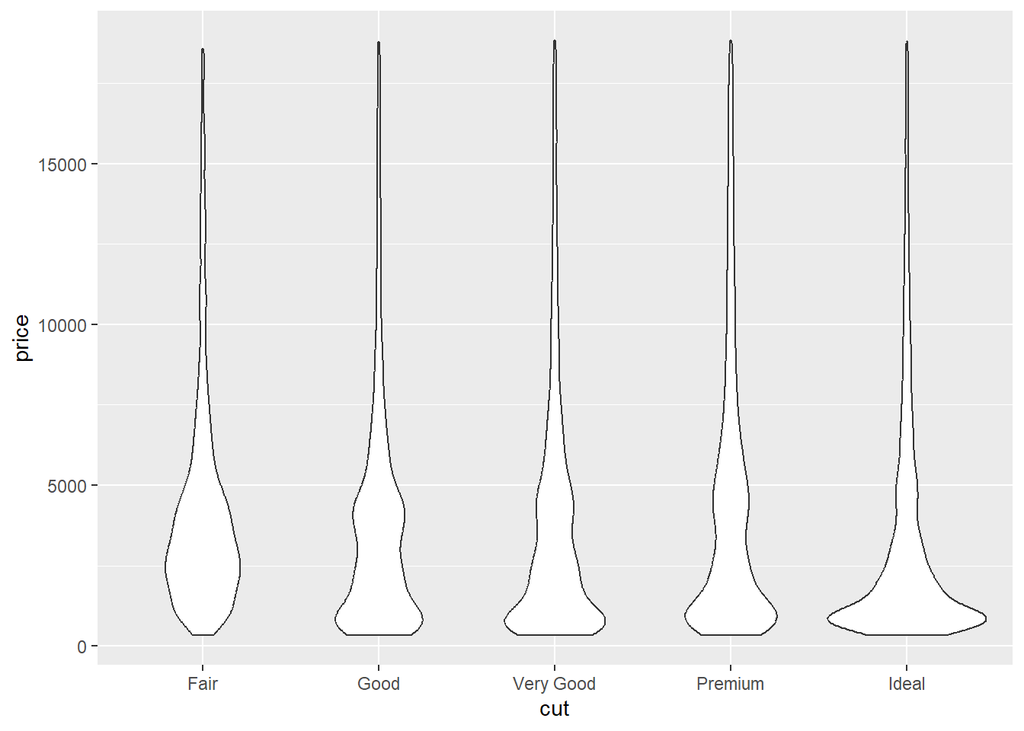

```r
ggplot(diamonds,aes(x=cut,y=price))+geom_violin()
```

Don’t leave violin plot alone.

Combine it with box plot.

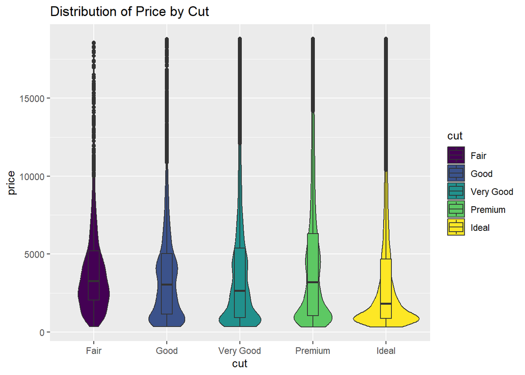

```r
ggplot(diamonds,aes(x=cut,y=price,fill=cut))+geom_violin()+geom_boxplot(width=0.15)+labs(title="Distribution of Price by Cut")
```

```r
#width sets the size of box plot
```

**Extra**

`statsExpressions` package

This package helps you to print the output of the statistical test on the related plots. It can be applicable for many types of plot.

For other examples, please click [here.](https://github.com/indrajeetpatil/statsexpressions)

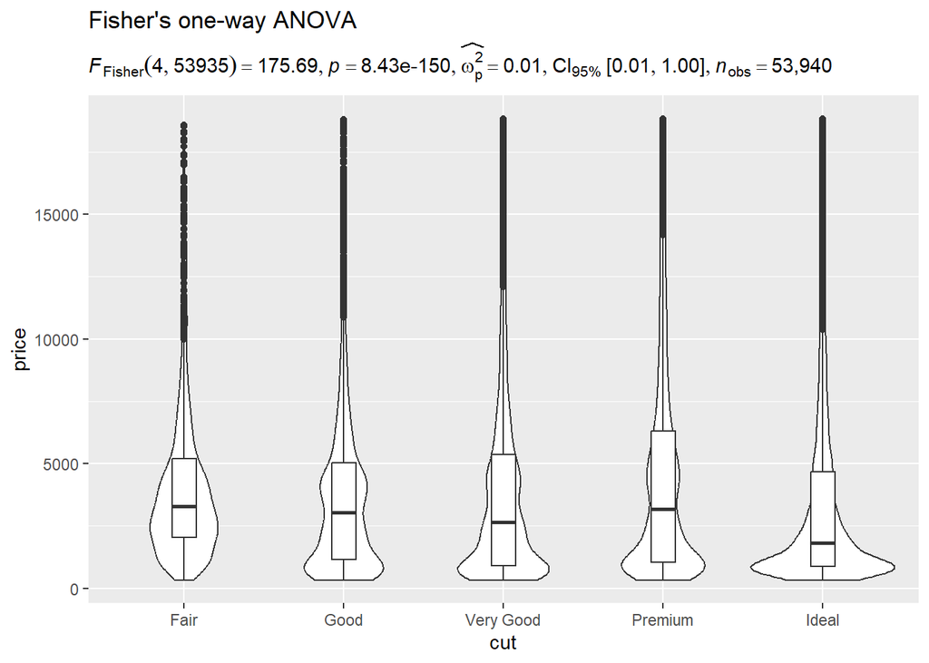

```r
library(ggplot2)
library(ggforce)
library(statsExpressions)
# plot with subtitle
ggplot(diamonds,aes(x=cut,y=price)) +
  geom_violin() +geom_boxplot(width=0.15)+
  labs(
    title = "Fisher's one-way ANOVA",
    subtitle = oneway_anova(diamonds, cut, price, var.equal = TRUE)$expression[[1]]
  )
```

**Consider first research question and answer this with different visual**

**What is the frequency distribution of cut?**

*Lollipop Chart:* Lollipop plot is basically a barplot, where the bar is transformed in a line and a dot. It shows the relationship between a numeric and a categorical variable. A lollipop is built using `geom_point()` for the circle, and `geom_segment()` for the stem.

```r
t = table(diamonds$cut)
df = data.frame(t)
df
```

```
##        Var1  Freq
## 1      Fair  1610
## 2      Good  4906
## 3 Very Good 12082
## 4   Premium 13791
## 5     Ideal 21551
```

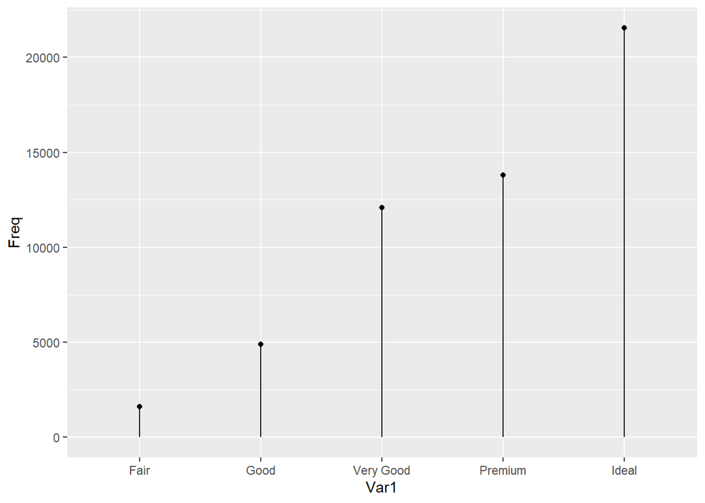

```r
ggplot(df,aes(x=Var1,y=Freq)) +geom_point() + geom_segment(aes(x=Var1, xend=Var1, y=0, yend=Freq))
```

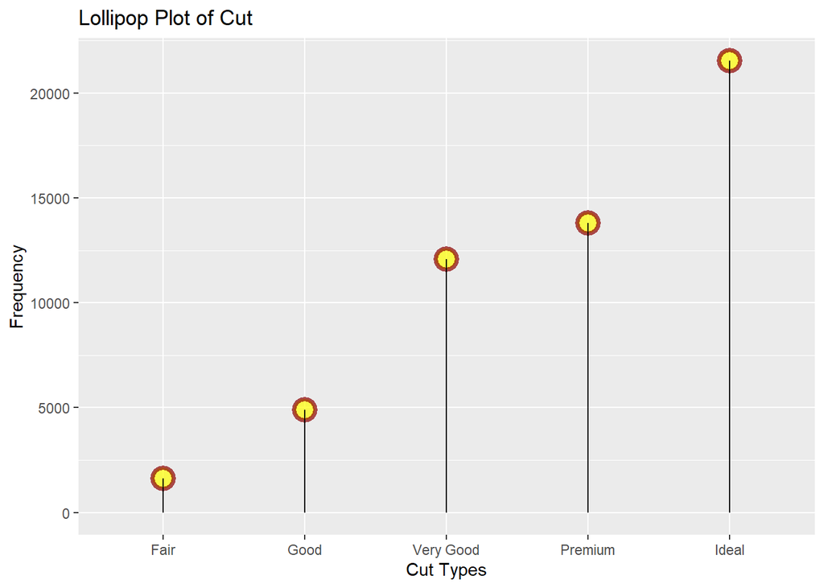

```r
ggplot(df,aes(x=Var1,y=Freq)) +geom_point(size=5, color="darkred", fill="yellow", alpha=0.7, shape=21, stroke=2) +geom_segment(aes(x=Var1, xend=Var1, y=0, yend=Freq))+labs(title="Lollipop Plot of Cut",x="Cut Types",y="Frequency")
```

*Dumbell Plot:* Dumbell plot, a.k.a Dumbell Chart, is great for displaying changes between two points in time, two conditions or differences between two groups.

Before drawing this plot, your data set should be ready for it.

**Data Manipulation**

```r
min_price = aggregate(depth~cut,data=diamonds,min)
max_price = aggregate(depth~cut,data=diamonds,max)
dumbell_data=cbind(min_price,max_price)
dumbell_data
```

```
##         cut depth       cut depth
## 1      Fair  43.0      Fair  79.0
## 2      Good  54.3      Good  67.0
## 3 Very Good  56.8 Very Good  64.9
## 4   Premium  58.0   Premium  63.0
## 5     Ideal  43.0     Ideal  66.7
```

Not enough..

```r
dumbell_data = dumbell_data[,-3]
colnames(dumbell_data) = c("cut","min","max")
dumbell_data
```

```
##         cut  min  max
## 1      Fair 43.0 79.0
## 2      Good 54.3 67.0
## 3 Very Good 56.8 64.9
## 4   Premium 58.0 63.0
## 5     Ideal 43.0 66.7
```

```r
library(ggalt)
```

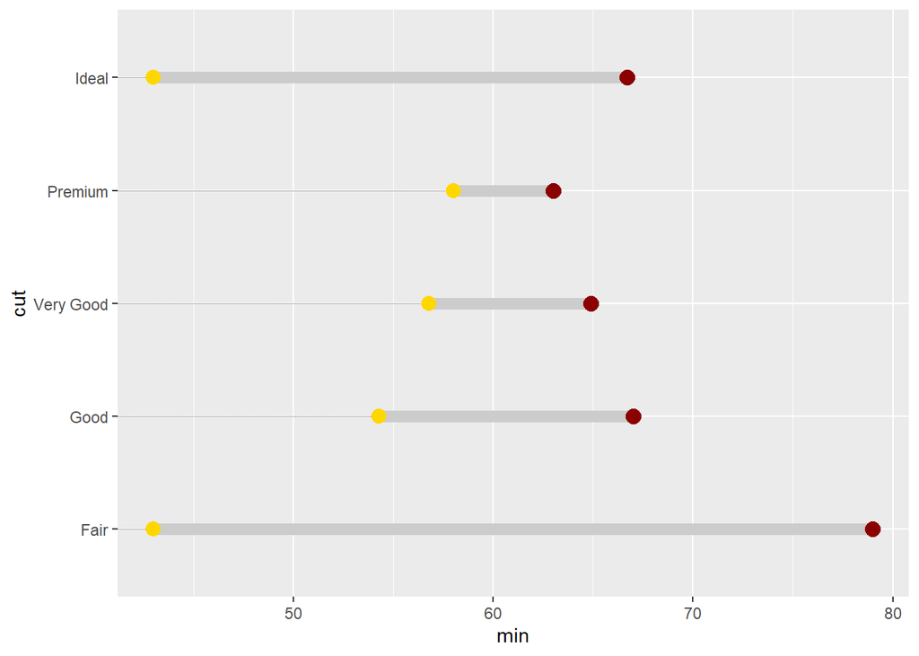

```r
ggplot(dumbell_data, aes(y=cut, x=min, xend=max)) +
  geom_dumbbell(size=3, color="gray80",
                colour_x = "gold1", colour_xend = "darkred",
                dot_guide=TRUE, dot_guide_size=0.1)
```

It is seen that depth of fair diamonds have the highest variability. The premium diamonds have more consistent depth value.

*Line Plot:* : A line plot is a type of graph that displays data points connected by straight lines, typically used to visualize the trend or pattern of a continuous variable over a continuous range. It is effective in showing the relationship between two variables and can reveal trends, fluctuations, or changes in the data over time or across different categories.

Consider `economics` data.

```r
head(economics)
```

```
## # A tibble: 6 x 6
##   date         pce    pop psavert uempmed unemploy
##   <date>     <dbl>  <dbl>   <dbl>   <dbl>    <dbl>
## 1 1967-07-01  507. 198712    12.6     4.5     2944
## 2 1967-08-01  510. 198911    12.6     4.7     2945
## 3 1967-09-01  516. 199113    11.9     4.6     2958
## 4 1967-10-01  512. 199311    12.9     4.9     3143
## 5 1967-11-01  517. 199498    12.8     4.7     3066
## 6 1967-12-01  525. 199657    11.8     4.8     3018
```

We use `geom_line()` geometric function to produce a line plot. Note that we use two variables to draw a line plot.

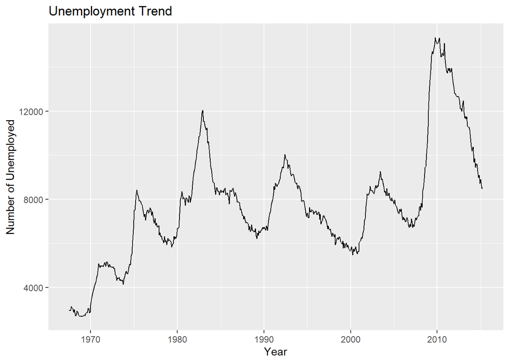

```r
# Create a line plot with the economics dataset
ggplot(data = economics, aes(x = date, y = unemploy)) +
  geom_line() +
  labs(x = "Year", y = "Number of Unemployed", title = "Unemployment Trend")
```

It is also possible to draw multiple lines on the same plot.

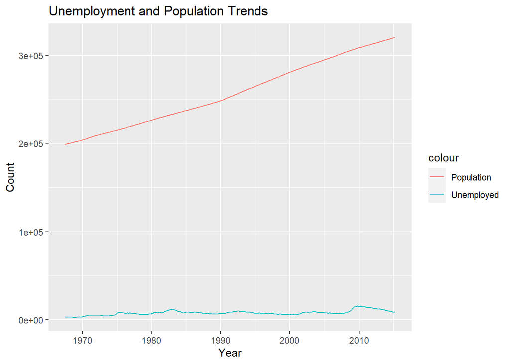

```r
# Create a line plot with two lines using the economics dataset
ggplot(data = economics, aes(x = date)) +
  geom_line(aes(y = unemploy, color = "Unemployed")) +
  geom_line(aes(y = pop, color = "Population")) +
  labs(x = "Year", y = "Count", title = "Unemployment and Population Trends")
```